# A Bioconductor workflow for the Bayesian Analysis of Spatial proteomics

Oliver M. Crook, Lisa Breckels, Kathryn Lilley, Paul D.W. Kirk and Laurent Gatto

31 October 2018

#### Package

pRoloc 1.23.1

# 1 Version

**R version**: R version 3.5.1 (2018-07-02)  
**Bioconductor version**: 3.8

# 2 Introduction

Quantifying uncertainty in the spatial distribution of proteins allows for novel insight into protein function. Many proteins live in a single location within the cell, however there are those that reside in mutiple locations and those that dynamically relocalise. Functional comparmentalisation of proteins allows the cell to control biomolecular pathways and biochemical process within the cell. Therefore, proteins with multiple localisation may have mutiple functional roles. Machine learning algorithms that fail to quantify uncertainty are unable to draw deeper insight into understanding cell biology.

We present a worflow for the Bayesian analysis of spatial proteomics using the t-augmented Gaussian mixture (TAGM) model proposed in:

> A Bayesian Mixture Modelling Approach For Spatial Proteomics Oliver M Crook, Claire M Mulvey, Paul D. W. Kirk, Kathryn S Lilley, Laurent Gatto bioRxiv 282269; doi: https://doi.org/10.1101/282269

The above manuscript provides a detailed description of the model, rigorous comparisons and testing on many spatial proteomics datasets and a case study on mouse pluripotent stem cells. Revisiting these details is not the purpose of this computational protocol, rather we present how to correctly use the software and provide step by step guidance. In brief, the TAGM model posits that each annotated sub-cellular niche can be described by a Gaussian distribution. Thus the full complement of proteins within the cell is captured as a mixture of Gaussians. The highly dynamic nature of the cell means that many proteins are not well captured by any of these multivariate Gaussian distributions, and thus the model also includes an outlier component, mathematically desribed as multivariate student’s t distribution. The heavy tails of the t distribution allow it to better capture dispersed proteins.

To perform inference in the TAGM model there are two approaches. The first allows us to obtain *maximum a posteriori* estimates of posterior localisation probabilities; that is, the posterior probability that a protein localises to that class. Whilst this is a interpretable summary of the TAGM model it only provides point estimates. For a richer analysis, we present a Markov-chain Monte-Carlo method to beform fully Bayesian inference in our model, allowing us to obtain full posterior localisation distributions.

In this workflow, we are currently using the development version of `pRoloc` and current Bioconductor version of `pRolocdata` and `MSnbase`. The pacakge `pRoloc` contains algorithms and methods for analysing spatial proteomics data, building on the `MSnset` structure provided in `MSnbase`. The `pRolocdata` package provides many annotated datasets from a variety of species and experimental procedures. The following code chunk installs the require pacakges.

```r
 require(devtools)
install_github("lgatto/pRoloc")
#BiocManager::install(c("MSnbase", "pRolocdata"))
require(pRolocdata)
```

# 3 Getting started

We assume that we have a spatial proteomics dataset provided by an `MSnset`. For information on how to import data, perform basic data processing, quality control, supervised machine learning and transfer learning see Lisa’s workflow. We use a spatial proteomics dataset on Mouse E14TG2a embryonic stem cells. The LOPIT protocol was used and normalised intensity of proteins from eight iTRAQ 8-plex labelled fraction are provided. The methods provided here are independent of labelling procedure, fractionation process or workflow. Examples of valid experimental protocols are LOPIT, hyperLOPIT, label-free methods such as PCP, and when fractionation is perform by differential centrifugation.

In the code chunk below we load the aforementioned dataset. The printout demonstrates that this experiment quantified 2031 proteins over 8 fractions.

```r
data("E14TG2aR")
print(E14TG2aR)
```

```
## MSnSet (storageMode: lockedEnvironment)
## assayData: 2031 features, 8 samples
##   element names: exprs
## protocolData: none
## phenoData
##   sampleNames: n113 n114 ... n121 (8 total)
##   varLabels: Fraction.information
##   varMetadata: labelDescription
## featureData
##   featureNames: Q62261 Q9JHU4 ... Q9EQ93 (2031 total)
##   fvarLabels: Uniprot.ID UniprotName ... markers (8 total)
##   fvarMetadata: labelDescription
## experimentData: use 'experimentData(object)'
## Annotation:
## - - - Processing information - - -
## Loaded on Thu Jul 16 15:02:29 2015.
## Normalised to sum of intensities.
## Added markers from  'mrk' marker vector. Thu Jul 16 15:02:29 2015
##  MSnbase version: 1.17.12
```

We can visualise the mouse stem cell dataset use the `plot2D` function. As we can see some of the classes overlap - it is there vital to perform uncertainty quantification when analysising this data.

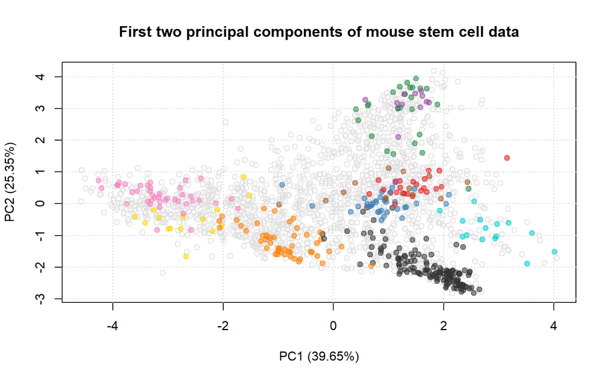

```r
plot2D(E14TG2aR, main = "First two principal components of mouse stem cell data")
```

We have found that the TAGM model sometimes fails due to floating point arithemtic errors. Error messages such at `error: chol(): decomposition failed` are indicative of this issue. Though theortically this shouldn’t happen and most of the time the issue doesn’t appear, it can occur. The failure can happen for a number of reasons such as proteins have almost identical profiles; highly correlated or co-linear fractions; and/or all quantitation values in a particular fraction are close to zero. We find performing variance stabilsation normalisation (vsn) can reduce the chances of numerical issues. The following code chunk demonstrates performing this normalisation within R. Though this step is not always necessary and if you experience no such issues then you should skip this step.

```r
E14TG2aR <- normalise(E14TG2aR, "vsn")
```

We can visualise the results again by using `plot2D`

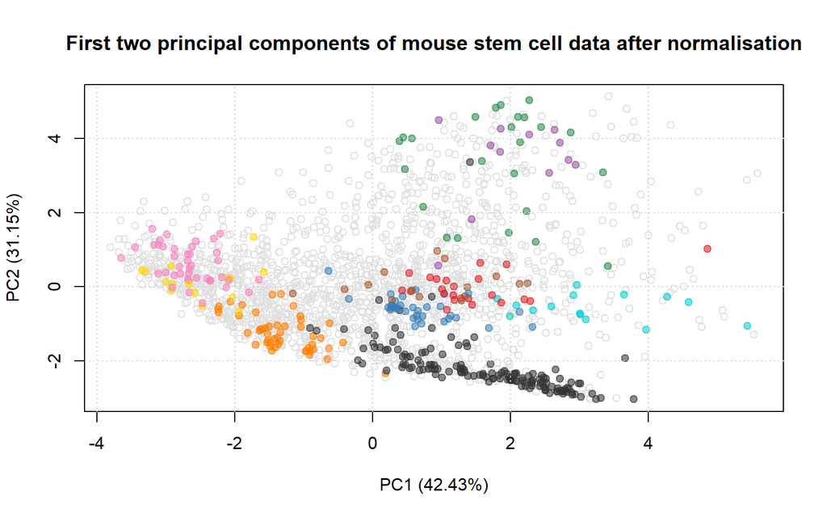

```r
plot2D(E14TG2aR, main = "First two principal components of mouse stem cell data after normalisation")
```

# 4 Methods: *TAGM MAP*

We can perform *maximum a posteriori* estimation to perform Bayesian inference in our model. The *maximum a posteriori* estimate equals the mode of the posterior distribution and can be used to provide a point estimate summary of the posterior localisation probabilities. It doesn’t provide samples from the posterior distribution, however an extended version of the expectation-maximisation (EM) algorithm can be used in our case, allowing fast inference. The code chunk below excutes the `tagmMapTrain` function for a default of 100 iteration. We use the default priors for simplicity and convenience, however they can be changed, which we explain later. The output is an object of class `MAPParams`.

```r
set.seed(2)
mapRes <- tagmMapTrain(E14TG2aR)
mapRes
```

```
## Object of class "MAPParams"
##  Method: MAP
```

The results of the modelling can be visualised with the `plotEllipse` function. The outer ellipse contains 99% of the total probability whilst the middle and inner ellipses contain 95% and 90% of the probability respectively. The centres of the clusters are represented by black circumpunct (circled dot).

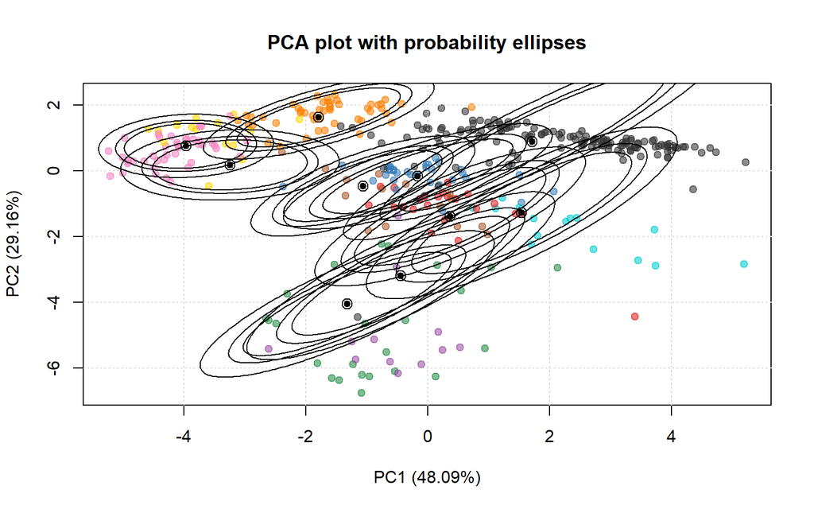

```r
plotEllipse(E14TG2aR, mapRes, main = "PCA plot with probability ellipses")
```

We can also plot the model in other principal components. The code chunk below plots the probability ellipses along the first and fourth prinipal component. The user can change the components visualised by altering the `dims` argument.

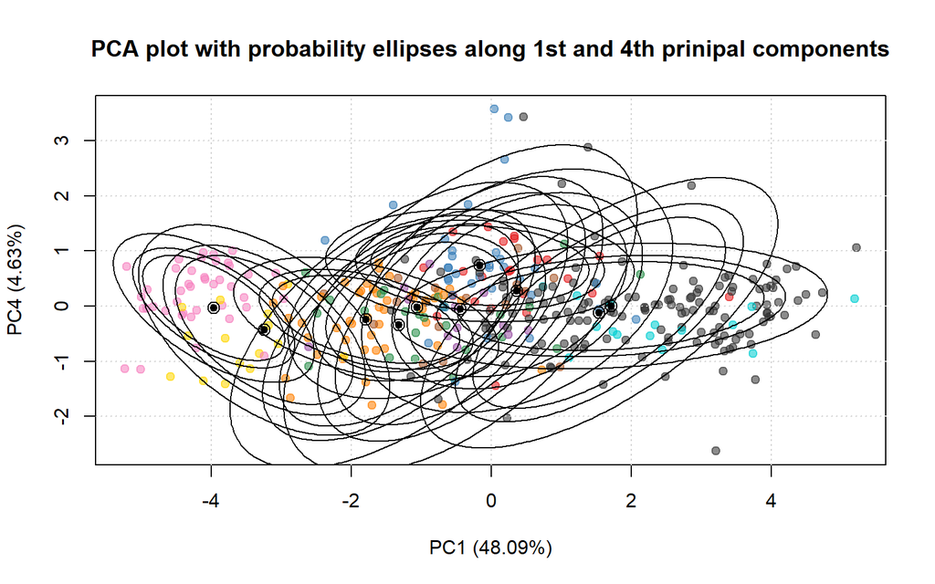

```r
plotEllipse(E14TG2aR, mapRes, dims = c(1, 4), main = "PCA plot with probability ellipses along 1st and 4th prinipal components")
```

The EM algorithm is iterative; that is, the algorithm iterates between an expectation step and a maximisation step until the value of the log-posterior doesn’t change. The value of the log-posterior at each iteration is contained within `posteriors` slot within the `MAPParams` object. The code chuck below plots the log posterior at each iteration and we see the algorithm rapidly plateaus and so we have acheived convergence. If convergence has not been reached during this time, increase the number of iteration by changing the parameter `numIter` in the `tagmMapTrain`. In practice, it is not unexpected to observe small fluctations due to numerical errors and users should not be concerned by this.

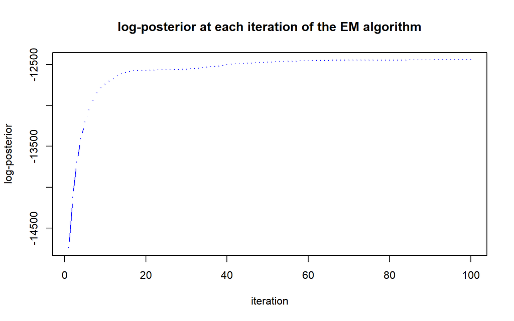

```r
plot(mapRes@posteriors$logposterior, type = "b", col = "blue", cex = 0.1, ylab = "log-posterior", xlab = "iteration", main = "log-posterior at each iteration of the EM algorithm")
```

The code chuck below uses the `MAPParams` object to classify the proteins of unknown localisation using `tagmPredict` function. This method appends new columns to the `fData` columns of the `MSnset`.

```r
E14TG2aR <- tagmPredict(E14TG2aR, mapRes)
```

The new feature variables that are generated are:

- `tagm.map.allocation`: the TAGM-MAP predictions for the most probable protein sub-cellular allocation.

```r
table(fData(E14TG2aR)$tagm.map.allocation)
```

```
##
##          40S Ribosome          60S Ribosome               Cytosol
##                   109                    53                   179
## Endoplasmic reticulum              Lysosome         Mitochondrion
##                   288                   157                   331
##   Nucleus - Chromatin   Nucleus - Nucleolus       Plasma membrane
##                   104                   335                   310
##            Proteasome
##                   165
```

- `tagm.map.probability`: the posterior probability for the protein sub-cellular allocations.

```r
summary(fData(E14TG2aR)$tagm.map.probability)
```

```
##    Min. 1st Qu.  Median    Mean 3rd Qu.    Max.
##  0.0000  0.9121  0.9898  0.9015  0.9998  1.0000
```

- `tagm.map.outlier`: the posterior probability for that protein to belong to the outlier component rather than any annotated component.

```r
summary(fData(E14TG2aR)$tagm.map.outlier)
```

```
##     Min.  1st Qu.   Median     Mean  3rd Qu.     Max.
## 0.000000 0.000105 0.001827 0.042451 0.008715 1.000000
```

We can visualise the results by scaling the pointer according the posterior localisation probabilities

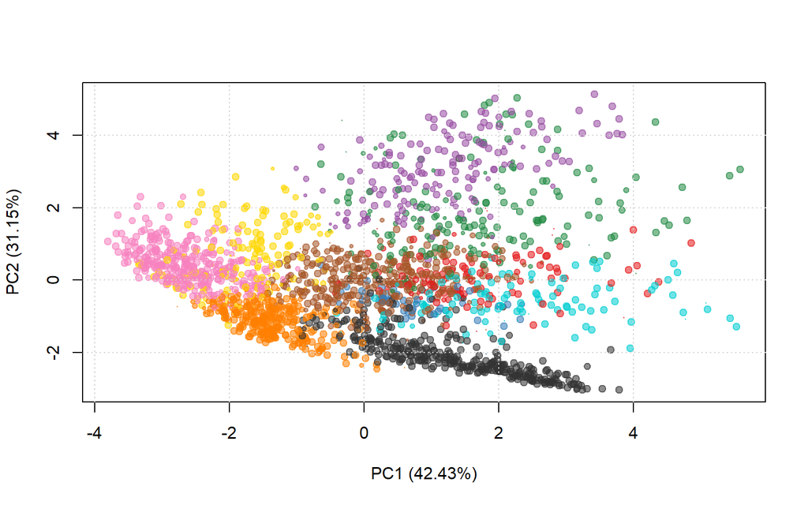

```r
ptsze <- fData(E14TG2aR)$tagm.map.probability

plot2D(E14TG2aR, fcol = "tagm.map.allocation", cex = ptsze)
```

The TAGM MAP method is easy to use and it is easy to check convergence, however it is limited in that it can only provide point estimates of the posterior distributions. To obtain the full posterior distribution we resort to using Markov-Chain Monte-Carlo methods. In our particular case, we use a so-called collapsed Gibbs sampler.

# 5 Methods: *TAGM MCMC* a brief overview

The TAGM MCMC method allows a fully Bayesian analysis of spatial proteomics datasets. It employs a collapsed Gibbs sampler to obtain samples from the posterior distribution of localisation probablities, providing a rich analysis of the data. This section demonstrates the advantage of taking a Bayesian approach and the biological information that can be extracted from this analysis.

The method is computationally intensive and requires at least modest processing power. Leaving the MCMC to run overnight on a modern desktop is usually sufficient, however this, of course, depends on the exact system properties. Do note expect the analysis to finish in a couple of hours on a medium specification laptop, for example.

To demonstrate the class structure and expected outputs of the TAGM MCMC method, we run a brief analysis on the a subsest of the `tan2009r1` dataset from the *pRolocdata* purely for illustration. This is to provide a bare bones analysis of these data without being held back by computational requirements. We perform a complete demonstration and provide precise details of the analysis of the stem cell dataset considered above in the next section.

```r
set.seed(1)
data(tan2009r1)
tan2009r1 <- tan2009r1[sample(nrow(tan2009r1), 400), ]
```

The first step is run two MCMC chains for a few iterations of the algorithm using the `tagmMcmcTrain` function. This function will generate a object of class `MCMCParams`. The summary slot of which is currently empty.

```r
library("pRoloc")
p <- tagmMcmcTrain(object = tan2009r1, numIter = 3,
                   burnin = 1, thin = 1, numChains = 2)
p
```

```
## Object of class "MCMCParams"
## Method: TAGM.MCMC
## Number of chains: 2
```

Information for each MCMC chain is contained within the chains slot. This information can be accessed manually if need. The function `MCMCProcess` populates the summary slot of the `MCMCParams` object

```r
p <- tagmMcmcProcess(p)
p
```

```
## Object of class "MCMCParams"
## Method: TAGM.MCMC
## Number of chains: 2
## Summary available
```

The summary slot has now been populated to include basic summaries of the `MCMCChains`, such as allocations and localisation probabilities. Protein information can be appended to the feature columns of the `MSnSet` by using the `tagmPredict` function, which extracts the required information from the summary slot of the `MCMCParams` object.

```r
res <- tagmPredict(object = tan2009r1, params = p)
```

One can access new features variables:

- `tagm.mcmc.allocation`: the TAGM-MCMC prediction for the most likely protein sub-cellular annotation.

```r
table(fData(res)$tagm.mcmc.allocation)
```

```
##
##  Cytoskeleton            ER         Golgi      Lysosome mitochondrion
##            12            98            21            10            40
##       Nucleus    Peroxisome            PM    Proteasome  Ribosome 40S
##            25             3           104            28            30
##  Ribosome 60S
##            29
```

- `tagm.mcmc.probability`: the posterior probability for the protein sub-cellular allocations.

```r
summary(fData(res)$tagm.mcmc.probability)
```

```
##    Min. 1st Qu.  Median    Mean 3rd Qu.    Max.
##  0.3367  0.8988  0.9857  0.9074  1.0000  1.0000
```

As well as other useful summaries of the MCMC methods:

- `tagm.mcmc.outlier` the posterior probability for the protein to belong to the outlier component.
- `tagm.mcmc.probability.lowerquantile` and `tagm.mcmc.probability.upperquantile` are the lower and upper boundaries to the equi-tailed 95% credible interval of `tagm.mcmc.probability`.
- `tagm.mcmc.mean.shannon` a Monte-Carlo averaged shannon entropy, which is a measure of uncertainty in the allocations.

# 6 Methods: *TAGM MCMC* the details

```r
load("C:/Users/OllyC/Desktop/TAGMworkflow/tagmE14.rda")
```

This section explain how to manually manipulate the MCMC output of the TAGM model. The data file ‘tagmE14.rda’ is available online and is not directly loaded into this package for size. The file itself if around 500mb, which is too large to directly load into this package. The following code, which is not evaluated, was used to produce the `tagmE14` MCMCParams object. We run the MCMC algorithm for 20000 iterations with 10000 iterations discarded for burnin. We then thin the chain by 20. We ran 6 chains in parallel and so we obtain 500 samples for each of the 6 chains, totalling 3000 samples.

```r
tagmE14 <- tagmMcmcTrain(E14TG2aR2,
                         numIter = 20000,
                         burnin = 10000,
                         thin = 20,
                         numChains = 6)
```

Manually inspecting the object we see that it is a `MCMCParams` object with 6 chains

```r
tagmE14
```

```
## Object of class "MCMCParams"
## Method: TAGM.MCMC
## Number of chains: 6
```

## 6.1 Data exploration and Convergence diagnostics

We first assess converged using a parallel chains approach. Producing multiple chains is benifical not only for computational advantages but also for analysis of convergence of our chains.

```r
## Get number of chains
nChains <- length(tagmE14)
nChains
```

```
## [1] 6
```

The following code chunks sets up a manual convegence diagnostic check. We make use of objects and methods in the package *coda* to peform this analysis [@coda]. Our function below automatically coerces our objects into *coda* for ease of analysis. We calculate the total number of outliers at each iteration of each chain and if the algorithm has converged this number should be the same (or very similar) across all 6 chains. We can observe this from the trace plots and histrograms for each MCMC chain. Unconverged chains are discharded from downstream analysis.

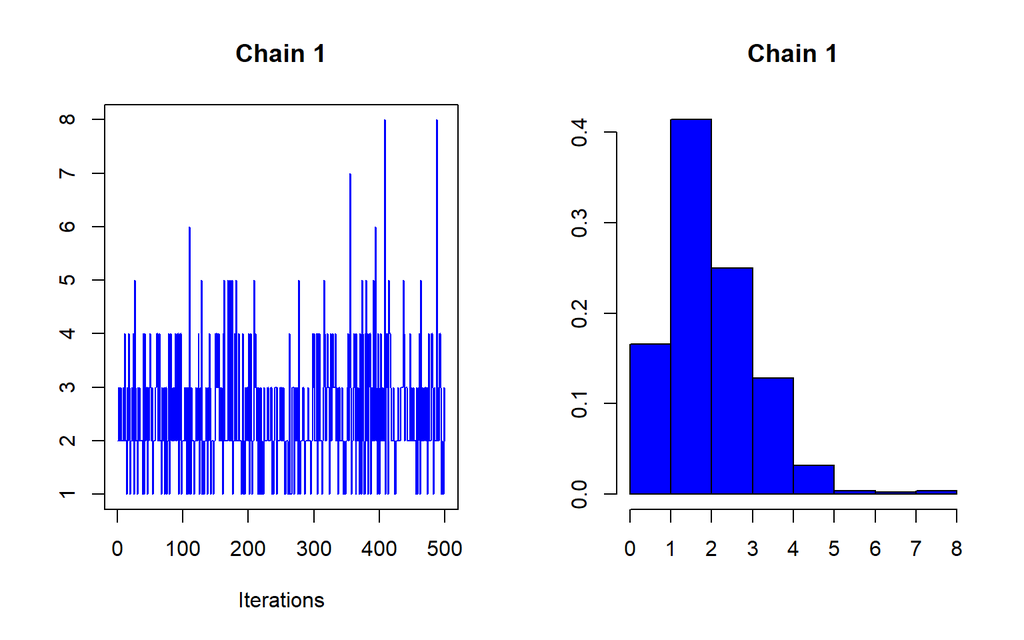

```r
## Convergence diagnostic to see if more we need to discard any
## iterations or entire chains: compute the number of outliers for
## each iteration for each chain
out <- mcmc_get_outliers(tagmE14)

## Using coda S3 objects to produce trace plots and histograms
plot(out[[1]], col = "blue",   main = "Chain 1")
```

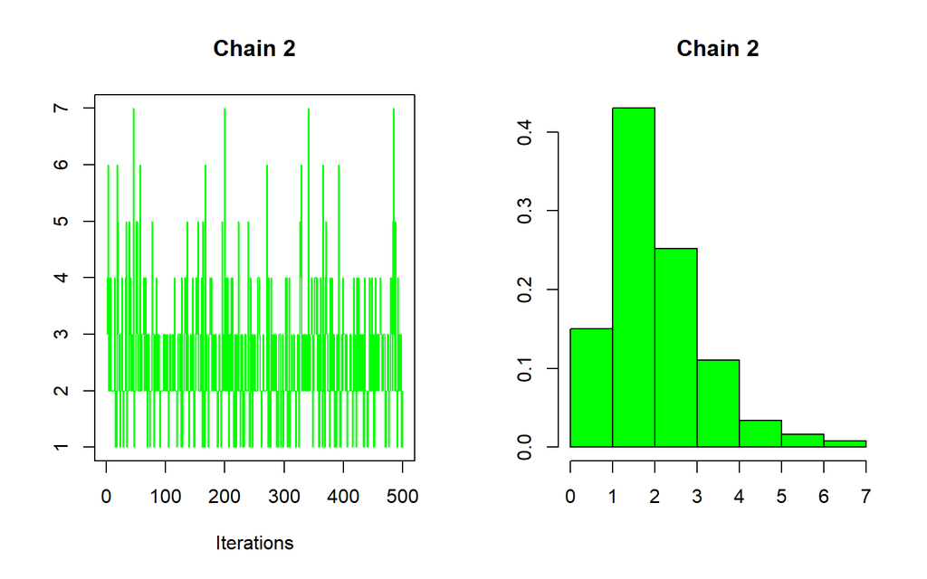

```r
plot(out[[2]], col = "green",  main = "Chain 2")
```

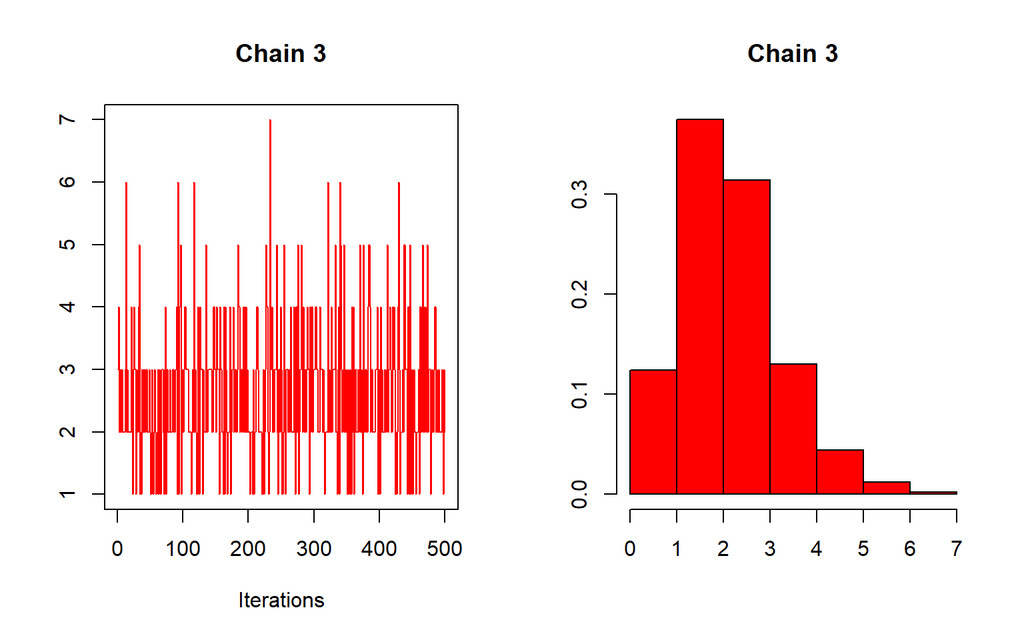

```r
plot(out[[3]], col = "red",    main = "Chain 3")
```

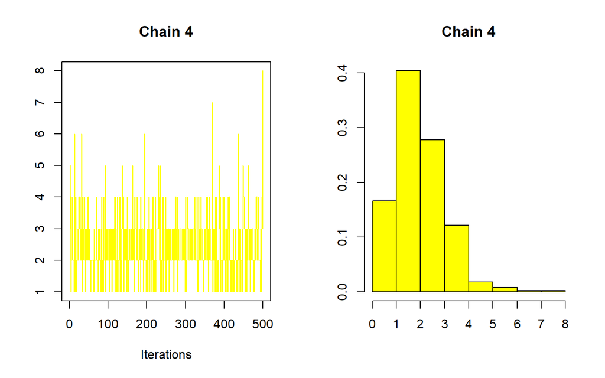

```r
plot(out[[4]], col = "yellow", main = "Chain 4")
```

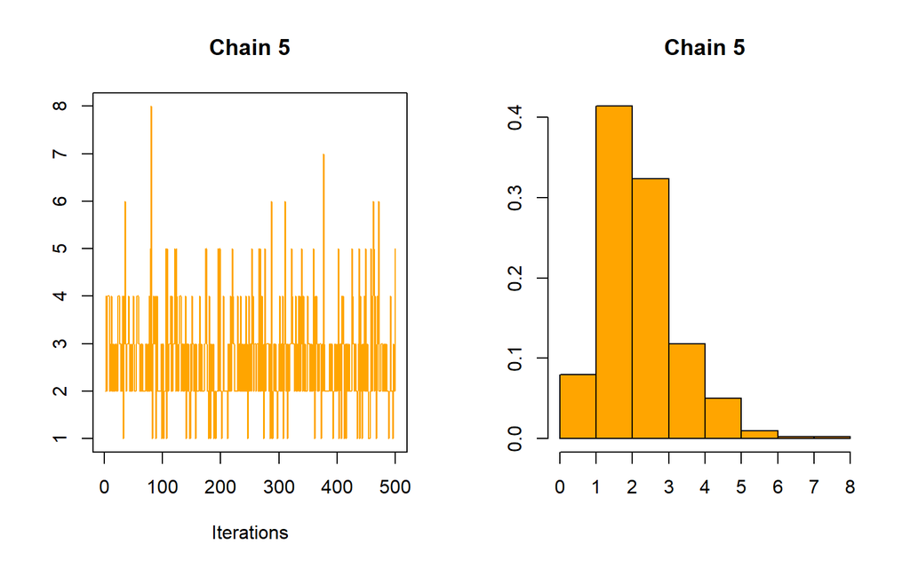

```r
plot(out[[5]], col = "orange", main = "Chain 5")
```

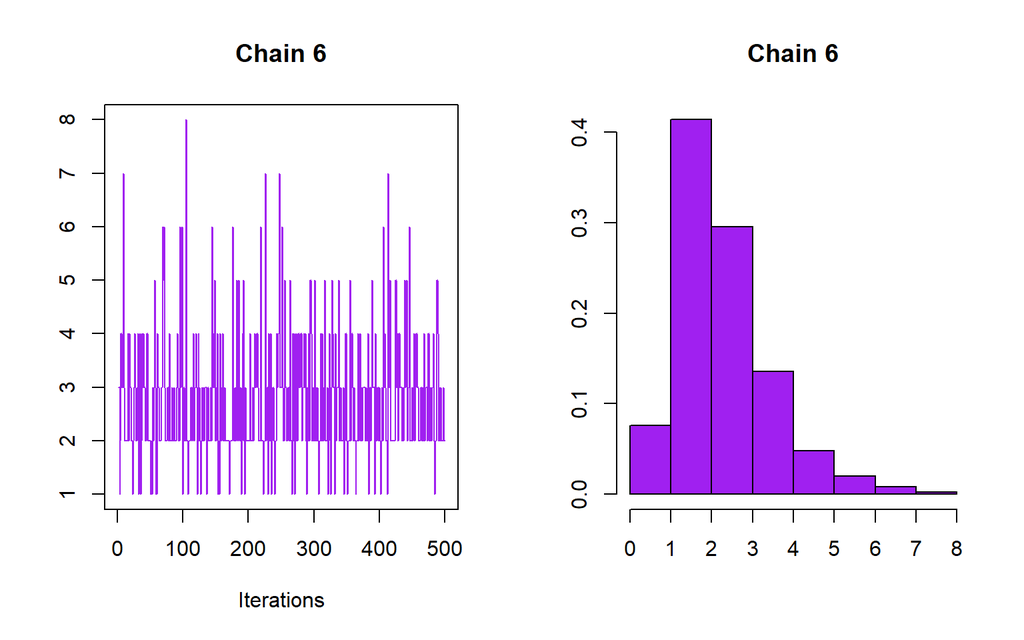

```r
plot(out[[6]], col = "purple", main = "Chain 6")
```

All of the chains are are oscillating around 2.5 and demonstrate similar structure. This is indicative of convergence. We can use the *coda* package to produce summaries of our chains. Here is the `coda` summary for the first chain.

```r
## all chains average around 2.5 outliers
summary(out[[1]])
```

```
##
## Iterations = 1:500
## Thinning interval = 1
## Number of chains = 1
## Sample size per chain = 500
##
## 1. Empirical mean and standard deviation for each variable,
##    plus standard error of the mean:
##
##           Mean             SD       Naive SE Time-series SE
##        2.48600        1.11368        0.04981        0.04981
##
## 2. Quantiles for each variable:
##
##  2.5%   25%   50%   75% 97.5%
##     1     2     2     3     5
```

### 6.1.1 Applying the Gelman Diagnostic

```r
## Can check gelman diagnostic for convergence (values less than <1.05
## are good for convergence)
gelman.diag(out, transform = TRUE) ## the Upper C.I. is 1.03 so mcmc has likely converged
```

```
## Potential scale reduction factors:
##
##      Point est. Upper C.I.
## [1,]       1.01       1.03
```

We can also look at the Gelman diagnostics statistics for groups or pairs of chains.

```r
## We can also check individual pairs of chains for convergence
gelman.diag(out[1:3], transform = TRUE) # the upper C.I is 1.02
```

```
## Potential scale reduction factors:
##
##      Point est. Upper C.I.
## [1,]       1.01       1.02
```

```r
gelman.diag(out[c(2,5)], transform = TRUE) # the upper C.I is 1.08
```

```
## Potential scale reduction factors:
##
##      Point est. Upper C.I.
## [1,]       1.02       1.08
```

Aswell as outliers, we can look at the mean component allocation at each iteration of the MCMC algorithm and as before we produce trace plots of this quantity.

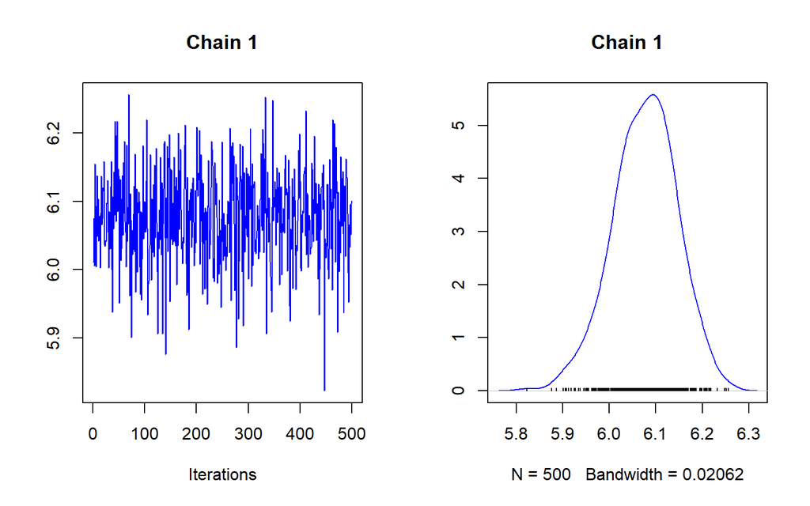

```r
# Compute the mean component allocation at each mcmc iterations
meanAlloc <- mcmc_get_meanComponent(tagmE14)


plot(meanAlloc[[1]], col = "blue",   main = "Chain 1")
```

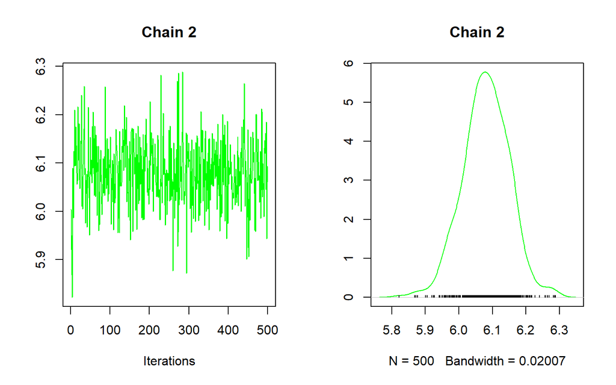

```r
plot(meanAlloc[[2]], col = "green",  main = "Chain 2")
```

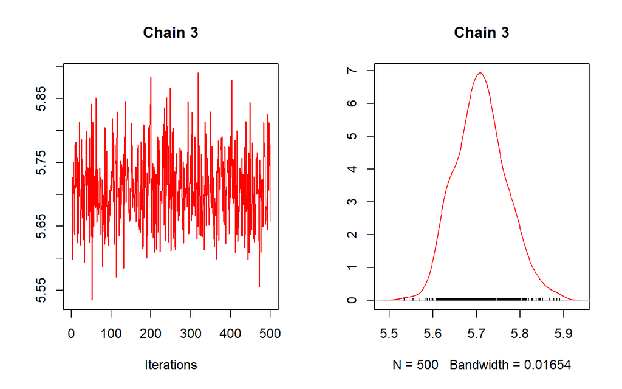

```r
plot(meanAlloc[[3]], col = "red",    main = "Chain 3")
```

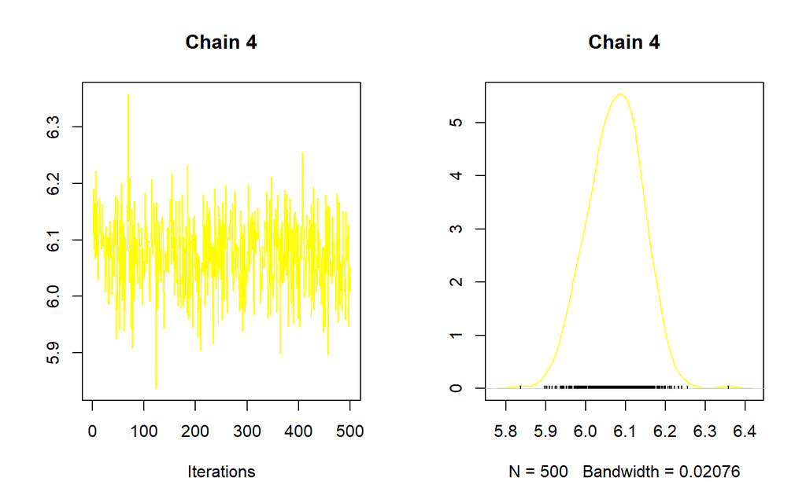

```r
plot(meanAlloc[[4]], col = "yellow", main = "Chain 4")
```

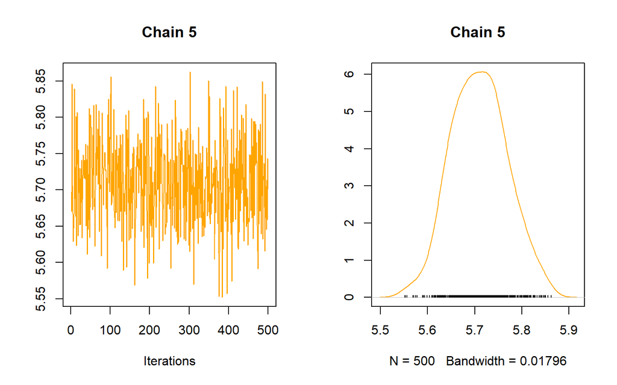

```r
plot(meanAlloc[[5]], col = "orange", main = "Chain 5")
```

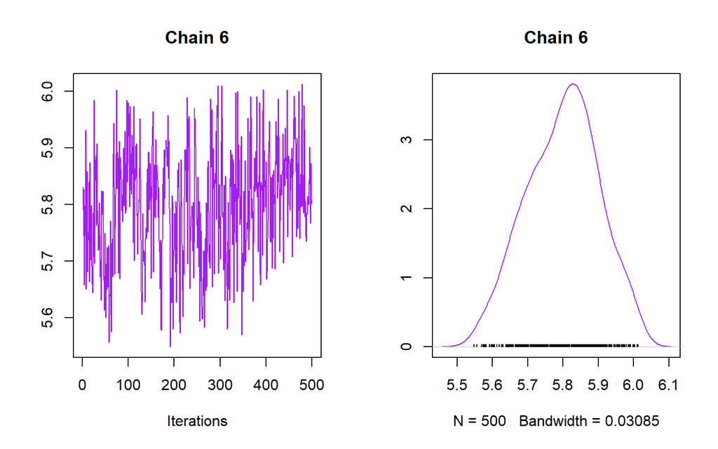

```r
plot(meanAlloc[[6]], col = "purple", main = "Chain 6")
```

As before we can produce summaries of the data.

```r
summary(meanAlloc[[1]])
```

```
##
## Iterations = 1:500
## Thinning interval = 1
## Number of chains = 1
## Sample size per chain = 500
##
## 1. Empirical mean and standard deviation for each variable,
##    plus standard error of the mean:
##
##           Mean             SD       Naive SE Time-series SE
##       6.076683       0.068538       0.003065       0.003271
##
## 2. Quantiles for each variable:
##
##  2.5%   25%   50%   75% 97.5%
## 5.934 6.033 6.081 6.123 6.205
```

We can already observe that there are difference between these chains and they oscillate around slightly different values, this raises suspicion that some of the chains may not have converged. We again apply the Gelamn diagnostics to these summaries.

```r
gelman.diag(meanAlloc)
```

```
## Potential scale reduction factors:
##
##      Point est. Upper C.I.
## [1,]       3.38       5.46
```

```r
gelman.diag(meanAlloc[c(1,2,4)])
```

```
## Potential scale reduction factors:
##
##      Point est. Upper C.I.
## [1,]          1       1.01
```

For a further check, we can look at the mean outlier probability at each iteration of the MCMC algorithm and again computing the Gelman diagnostics between chains $1,2$ and $4$. An $\hat(R)$ statistics of $1$ is indicative of convergence

```r
meanoutProb <- mcmc_get_meanoutliersProb(tagmE14)
gelman.diag(meanoutProb[c(1,2,4)])
```

```
## Potential scale reduction factors:
##
##      Point est. Upper C.I.
## [1,]          1          1
```

### 6.1.2 Applying the Geweke Diagnostic

```r
geweke_test(out)
```

```
##            chain 1   chain 2     chain 3    chain 4   chain 5    chain 6
## z.value -0.9201585 1.2916455 -2.43855877 1.69642764 1.6253508 -0.6003274
## p.value  0.3574900 0.1964799  0.01474596 0.08980492 0.1040878  0.5482881
```

```r
geweke_test(meanAlloc)
```

```
##           chain 1     chain 2   chain 3    chain 4   chain 5      chain 6
## z.value 0.4307900 -0.08817564 0.1194190 1.82904303 0.7542722 -3.197185476
## p.value 0.6666211  0.92973708 0.9049434 0.06739316 0.4506858  0.001387757
```

```r
geweke_test(meanoutProb)
```

```
##            chain 1   chain 2    chain 3   chain 4   chain 5    chain 6
## z.value -0.8845583 1.6385473 -0.8954649 1.0480938 0.6630499 -1.0246155
## p.value  0.3763949 0.1013076  0.3705386 0.2945954 0.5072986  0.3055447
```

The first test suggest chain 3 has not converged whilst the second test suggests that chain 6 has not converged supporting our earlier beliefs that these chains have not conveged. Users can use this method to explore other outputs should they wish.

An important question at this point is if removing early portion of the chain might lead to improvment of the convergence diagonistics. This my particularly relevant if a chain converges some iterations after our `burin` specified orginally. For example let us take the first Geweke test above, which suggested chain 3 had not converged and see if discarding the initial $10\%$ of the chain improves the statistic. The function below removes $50$ samples , informaly known as burning, from the beginning of each chain and the output shows that we now have $450$ samples in each chain.

```r
burntagmE14 <- mcmc_burn_chains(tagmE14, 50)
burntagmE14@chains@chains
```

```
## [[1]]
## Object of class "MCMCChain"
##  Number of components: 10
##  Number of proteins: 1663
##  Number of iterations: 450
##
## [[2]]
## Object of class "MCMCChain"
##  Number of components: 10
##  Number of proteins: 1663
##  Number of iterations: 450
##
## [[3]]
## Object of class "MCMCChain"
##  Number of components: 10
##  Number of proteins: 1663
##  Number of iterations: 450
##
## [[4]]
## Object of class "MCMCChain"
##  Number of components: 10
##  Number of proteins: 1663
##  Number of iterations: 450
##
## [[5]]
## Object of class "MCMCChain"
##  Number of components: 10
##  Number of proteins: 1663
##  Number of iterations: 450
##
## [[6]]
## Object of class "MCMCChain"
##  Number of components: 10
##  Number of proteins: 1663
##  Number of iterations: 450
```

The following function recomputes the number of outliers in each chain at each iteration of each Markov-chain.

```r
newout <- mcmc_get_outliers(burntagmE14)
```

The code chuck below compute the Geweke diagonstic for this new truncated chain and demonstrates that chain 3 has an improved Geweke diagnostic. Thus, in practice, it maybe useful to remove iterations from the beginning of the chain. However, as chain 3 did not pass the Gelman diagnostics we still discard it from downstream analysis.

```r
geweke_test(newout)
```

```
##            chain 1   chain 2    chain 3     chain 4   chain 5    chain 6
## z.value -0.4375964 0.7167981 -1.8993795 -1.77905509 0.4345828 -0.2522779
## p.value  0.6616789 0.4734987  0.0575146  0.07523073 0.6638653  0.8008262
```

## 6.2 Processing converged chains